### [WWS 586a] Problem Set 4

For these exercises we will be using the Global Terrorism Database (GTD) which can be found on Kaggle: https://www.kaggle.com/START-UMD/gtd/data. The GTD contains a great deal of information about terrorist events and contains roughly 170,000 such events.

### Due Date and Time

Due on Friday, April 27th at 11:59PM

### Guidelines

All problem sets must be submitted as two files:

1. A *R Markdown* file with the following format: “lastname_firstname_ps4.Rmd”. Ie. for me this would be: “anastasopoulos_jason_ps4.Rmd”
2. A compiled *R Markdown* file in HTML with the following format: “lastname_firstname_ps4.html” Ie. for me this would be: “anastasopoulos_jason_ps4.html”

Please only fill in the sections labelled “YOUR CODE HERE”

### Learning about assassinations and bombings through random forests

For this problem set, we will be taking the training wheels off and you will have to use your discretion to train a model using random forests.

The goal of this portion of the assignment is to build a machine learning classifier that will enable you to predict assasination events as a function of the features in the data.

Assasinations are labeled as “1” in the variable “attacktype1” within the GTD and bombings are labeled as “3”. Using whichever features you would like and whichever package you would like, train two random forests classifiers to predict assassinations and bombings using an 80/20 training test split.

Report the: accuracy, specificity, sensitivity and F1 statistics of the classifiers that you trained for each model.

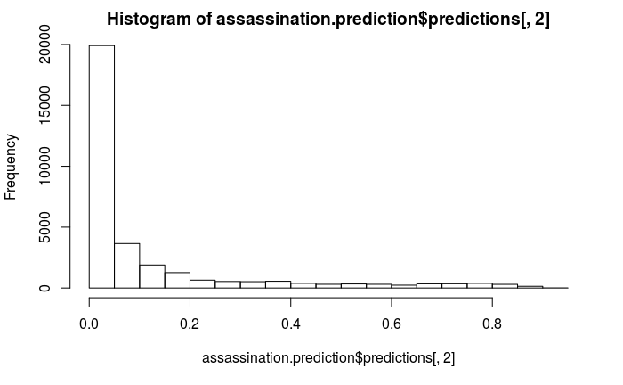

```r
hist(assassination.prediction$predictions[,2])
confusion <- table(binary.cutoff, factor(valid.set$attacktype1))
confusion
```

```
binary.cutoff     0     1
            0 27986  1708
            1   474  1966
```

```r
assassination.TP = confusion[2,2]
assassination.TN = confusion[1,1]
assassination.FP = confusion[2,1]
assassination.FN = confusion[1,2]
assassination.accuracy = (assassination.TP + assassination.TN) / (assassination.TP + assassination.TN + assassination.FP + assassination.FN)
assassination.specificity = assassination.TN / (assassination.TN + assassination.FP)
assassination.sensitivity = assassination.TP / (assassination.TP + assassination.FN)
assassination.F1 = (2 * assassination.TP) / ((2 * assassination.TP) + assassination.FP + assassination.FN)
sprintf("Accuracy: %f", assassination.accuracy)
```

```
[1] "Accuracy: 0.932097"
```

```r
sprintf("Specificity: %f", assassination.specificity)
```

```
[1] "Specificity: 0.983345"
```

```r
sprintf("Sensitivity: %f", assassination.sensitivity)
```

```
[1] "Sensitivity: 0.535112"
```

```r
sprintf("F1 Score: %f", assassination.F1)
```

```
[1] "F1 Score: 0.643114"
```

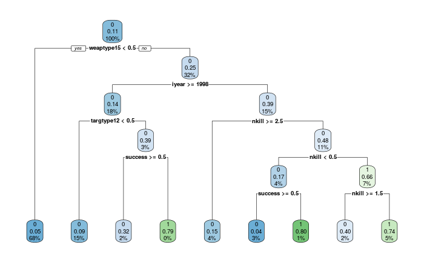

```r
assassination.tree.visualization <- rpart(factor(attacktype1)~., train.set)
rpart.plot(assassination.tree.visualization)
```

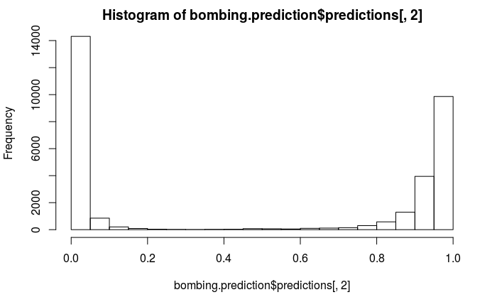

```r
bombing.df <- global.terrorism.df
bombing.df$attacktype1 <- ifelse(global.terrorism.df$attacktype1==3, 1, 0)
set.seed(100)
bombing.train <- sample(nrow(bombing.df), 0.8*nrow(bombing.df), replace = FALSE)
train.set <- bombing.df[bombing.train,]
valid.set <- bombing.df[-bombing.train,]
train.Control <- trainControl(method = "repeatedcv", number = 10, repeats = 1)
bombing.model <- ranger(factor(attacktype1) ~ ., data = train.set, importance = 'permutation',
                             write.forest=TRUE,
                            probability=TRUE)
bombing.prediction <- predict(bombing.model, valid.set)
binary.cutoff <-ifelse(bombing.prediction$predictions[,2] > 0.5, 1, 0)
hist(bombing.prediction$predictions[,2])
```

```r
confusion<-table(binary.cutoff, factor(valid.set$attacktype1))
confusion
```

```
binary.cutoff     0     1
            0 15390   281
            1   895 15568
```

```r
bombing.TP = confusion[2,2]
bombing.TN = confusion[1,1]
bombing.FP = confusion[2,1]
bombing.FN = confusion[1,2]
bombing.accuracy = (bombing.TP + bombing.TN) / (bombing.TP + bombing.TN + bombing.FP + bombing.FN)
bombing.specificity = bombing.TN / (bombing.TN + bombing.FP)
bombing.sensitivity = bombing.TP / (bombing.TP + bombing.FN)
bombing.F1 = (2 * bombing.TP) / ((2 * bombing.TP) + bombing.FP + bombing.FN)
sprintf("Accuracy: %f", bombing.accuracy)
```

```
[1] "Accuracy: 0.963403"
```

```r
sprintf("Specificity: %f", bombing.specificity)
```

```
[1] "Specificity: 0.945041"
```

```r
sprintf("Sensitivity: %f", bombing.sensitivity)
```

```
[1] "Sensitivity: 0.982270"
```

```r
sprintf("F1 Score: %f", bombing.F1)
```

```
[1] "F1 Score: 0.963605"
```

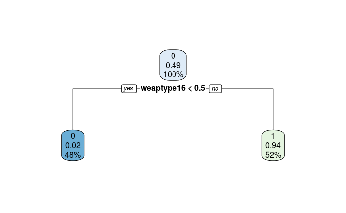

```r
bombing.tree.visualization <- rpart(factor(attacktype1)~., train.set)
rpart.plot(bombing.tree.visualization)
```

### 2. Which features predict assasinations and bombings best?

One of the best things about the random forests algorithm is that it allows us to understand which features contributed most to prediction success.

Create a plot of the top 10 most important features for each classifier using the % increase in MSE estimate to determine feature importance.

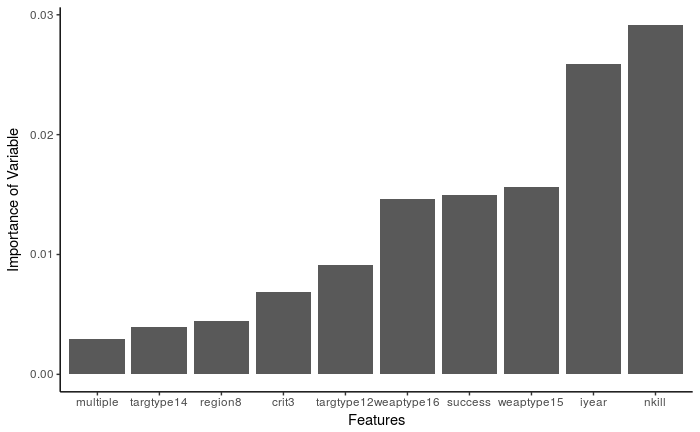

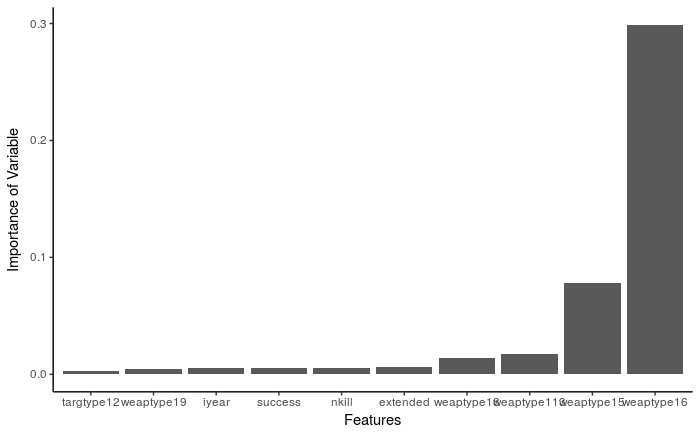

### 3. Lasso classification of assasinations and bombings

Using logistic regression with $L_1$ regularization (logistic regression lasso), train a model with the same features that you used for your decision tree classifiers above using an 80/20 train/test split.

Report the accuracy, specificity, sensistivity and F1 statistics for the trained logistic regression classifier for assasinations and bombings

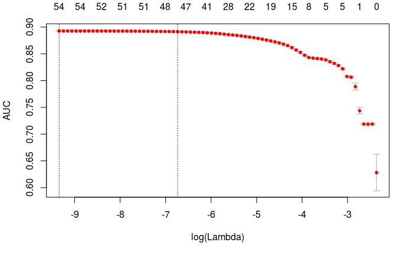

```r
library(glmnet)
train.x = as.matrix(assassination.train.set[,-1])
valid.x = as.matrix(assassination.valid.set[,-1])
assassination.lasso <- cv.glmnet(x = train.x, y=  as.factor(assassination.train.set[,1]), family='binomial', alpha=1,
                       standardize=TRUE, type.measure='auc')
plot(assassination.lasso)
```

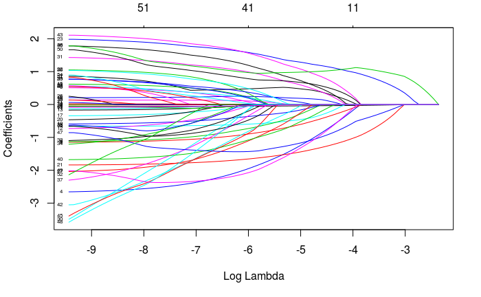

```r
plot(assassination.lasso$glmnet.fit, xvar="lambda", label=TRUE)
```

```r
assassination.lasso$lambda.min
```

```
[1] 8.776316e-05
```

```r
assassination.lasso$lambda.1se
```

```
[1] 0.001187477
```

```r
coef(assassination.lasso, s=assassination.lasso$lambda.min)
```

```
56 x 1 sparse Matrix of class "dgCMatrix"
                        1
(Intercept) 120.866696643
iyear        -0.061588993
imonth       -0.014600616
iday         -0.001247033
extended     -2.654074456
crit1        -0.662885074
crit2         0.508285088
crit3         0.857718088
multiple     -1.146943970
region1      -1.129561453
region2      -0.590510088
region3      -0.131557014
region4      -0.727991775
region5      -0.169864460
region6       0.021367096
region7       0.617825023
region8       0.207733934
region9      -0.342240880
region10      0.135533339
region11      .
region12     -0.461267663
success      -1.838167813
suicide       1.050159246
targtype12    1.982699759
targtype13    0.562991718
targtype14    0.568100945
targtype15    0.235435037
targtype16   -2.033821815
targtype17   -0.050834610
targtype18    0.770330517
targtype19   -3.408506802
targtype110   1.428345582
targtype111  -1.091469542
targtype112   0.543144895
targtype113  -1.197449886
targtype114   0.769784951
targtype115   1.035972797
targtype116  -2.285635108
targtype117   1.780363179
targtype118   0.135060085
targtype119  -1.676195261
targtype120   0.060921789
targtype121  -3.047814463
targtype122   2.107099393
weaptype12   -0.659208676
weaptype13   -3.308963543
weaptype15    1.782092623
weaptype16   -0.857152203
weaptype17   -3.495006155
weaptype18   -2.014833541
weaptype19    1.664763190
weaptype110   0.825466603
weaptype111  -2.058781137
weaptype112  -0.627945848
weaptype113   0.894458424
nkill        -0.082578768
```

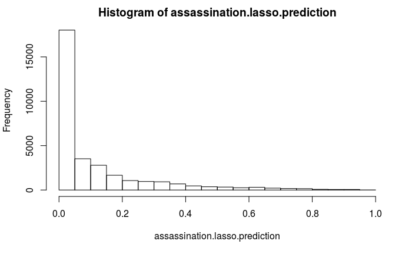

```r
assassination.lasso.prediction <- predict(assassination.lasso, valid.x, type="response")
binary.cutoff <- ifelse(assassination.lasso.prediction > 0.5, 1, 0)
hist(assassination.lasso.prediction)
```

```r
confusion <- table(binary.cutoff, factor(assassination.valid.set$attacktype1))
confusion
```

```
binary.cutoff     0     1
            0 27959  2527
            1   544  1104
```

```r
assassination.TP = confusion[2,2]
assassination.TN = confusion[1,1]
assassination.FP = confusion[2,1]
assassination.FN = confusion[1,2]
assassination.accuracy = (assassination.TP + assassination.TN) / (assassination.TP + assassination.TN + assassination.FP + assassination.FN)
assassination.specificity = assassination.TN / (assassination.TN + assassination.FP)
assassination.sensitivity = assassination.TP / (assassination.TP + assassination.FN)
assassination.F1 = (2 * assassination.TP) / ((2 * assassination.TP) + assassination.FP + assassination.FN)
sprintf("Accuracy: %f", assassination.accuracy)
```

```
[1] "Accuracy: 0.904431"
```

```r
sprintf("Specificity: %f", assassination.specificity)
```

```
[1] "Specificity: 0.980914"
```

```r
sprintf("Sensitivity: %f", assassination.sensitivity)
```

```
[1] "Sensitivity: 0.304048"
```

```r
sprintf("F1 Score: %f", assassination.F1)
```

```
[1] "F1 Score: 0.418261"
```

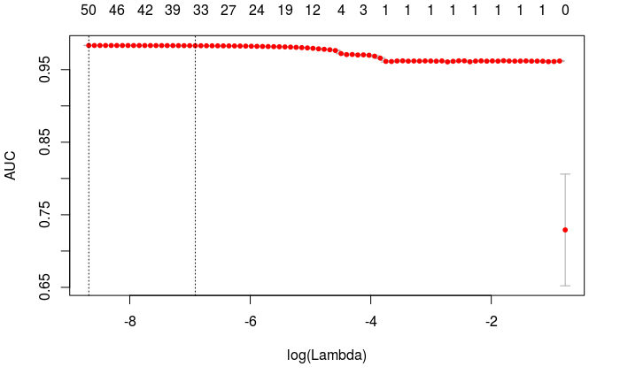

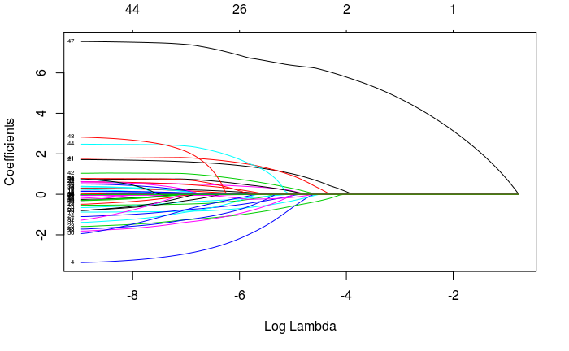

```r
train.x = as.matrix(bombing.train.set[,-1])
valid.x = as.matrix(bombing.valid.set[,-1])
bombing.lasso <- cv.glmnet(x = train.x, y=  as.factor(bombing.train.set[,1]), family='binomial', alpha=1,
                       standardize=TRUE, type.measure='auc')
plot(bombing.lasso)
plot(bombing.lasso$glmnet.fit, xvar="lambda", label=TRUE)

bombing.lasso$lambda.min
```

```
[1] 0.0001699015
```

```r
bombing.lasso$lambda.1se
```

```
[1] 0.0009951164
```

```r
coef(bombing.lasso, s=bombing.lasso$lambda.min)
```

```
56 x 1 sparse Matrix of class "dgCMatrix"
                        1
(Intercept) 42.4091629055
iyear       -0.0243340584
imonth      -0.0007259605
iday         0.0004928169
extended    -3.3502106673
crit1        0.3805018105
crit2        .
crit3        0.5696770650
multiple     0.2859901413
region1      0.0280164343
region2     -0.0218588621
region3      0.1391150062
region4      0.2228431508
region5      .
region6     -0.0460219213
region7     -0.2385876242
region8      0.2882364474
region9     -0.5367667162
region10     0.1526543165
region11    -0.8786017417
region12    -0.1548327691
success      1.7089967633
suicide      0.6164779075
targtype12  -1.5659943053
targtype13  -1.0748761109
targtype14  -0.6330971211
targtype15  -0.2452090920
targtype16  -0.7621842102
targtype17  -0.4597069320
targtype18  -0.0263831149
targtype19   0.4990632477
targtype110 -1.3542369333
targtype111  0.6167834165
targtype112 -0.7555010427
targtype113  .
targtype114 -0.2655768092
targtype115 -0.0263511924
targtype116  0.3622578478
targtype117 -1.7842451474
targtype118  .
targtype119  0.7376025294
targtype120  1.7781731214
targtype121  1.0439376054
targtype122 -1.6870760920
weaptype12   2.4709955813
weaptype13   .
weaptype15  -0.0595880410
weaptype16   7.5344224729
weaptype17   2.7966205608
weaptype18  -0.2930464853
weaptype19  -1.8387671468
weaptype110  0.7060811742
weaptype111 -1.1611867003
weaptype112  0.7140278160
weaptype113  0.7803857690
nkill       -0.0140803187
```

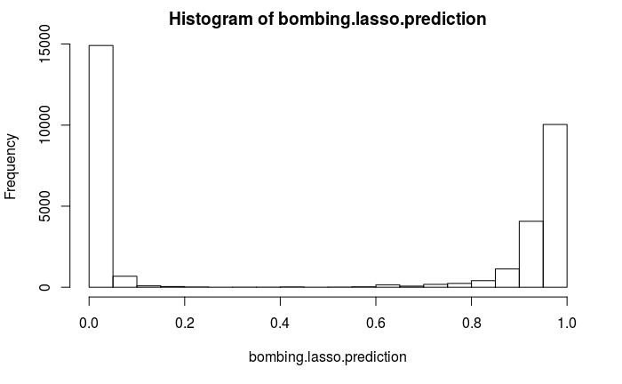

```r
bombing.lasso.prediction <- predict(bombing.lasso, valid.x, type="response")
binary.cutoff <- ifelse(bombing.lasso.prediction > 0.5, 1, 0)
hist(bombing.lasso.prediction)
```

```r
confusion <- table(binary.cutoff, factor(bombing.valid.set$attacktype1))
confusion
```

```
binary.cutoff     0     1
            0 15513   290
            1   958 15373
```

```r
bombing.TP = confusion[2,2]
bombing.TN = confusion[1,1]
bombing.FP = confusion[2,1]
bombing.FN = confusion[1,2]
bombing.accuracy = (bombing.TP + bombing.TN) / (bombing.TP + bombing.TN + bombing.FP + bombing.FN)
bombing.specificity = bombing.TN / (bombing.TN + bombing.FP)
bombing.sensitivity = bombing.TP / (bombing.TP + bombing.FN)
bombing.F1 = (2 * bombing.TP) / ((2 * bombing.TP) + bombing.FP + bombing.FN)
sprintf("Accuracy: %f", bombing.accuracy)
```

```
[1] "Accuracy: 0.961163"
```

```r
sprintf("Specificity: %f", bombing.specificity)
```

```
[1] "Specificity: 0.941837"
```

```r
sprintf("Sensitivity: %f", bombing.sensitivity)
```

```
[1] "Sensitivity: 0.981485"
```

```r
sprintf("F1 Score: %f", bombing.F1)
```

```
[1] "F1 Score: 0.960993"
```

### 4. Features predicting bombings and assisnations best using the lasso.

Create a plot of the top 10 most important features for each classifier using the coefficient estimates from the lasso model. As long as you standardized your data when you estimated the lasso model, the coefficient estimates will be on the same scale.

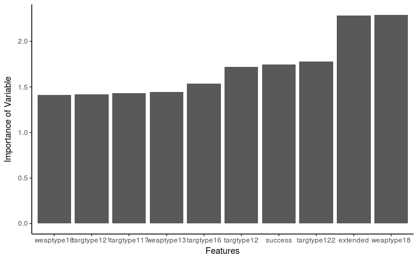

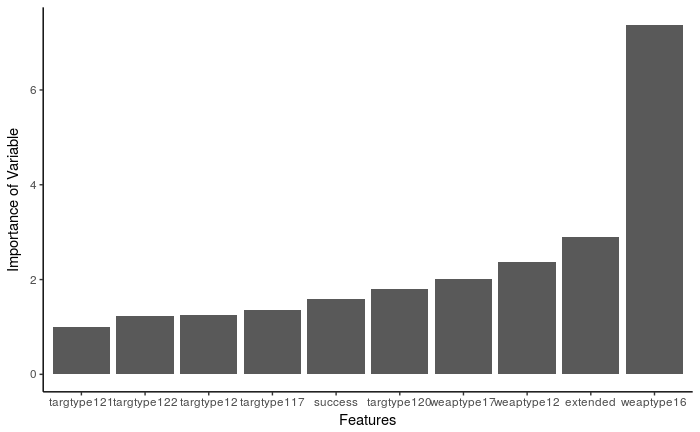